# v2_output

## EV Car Charging dataset

This dataset contains data related to the charging characteristics of electric vehicle (EV) batteries. The dataset includes various factors affecting battery performance, degradation, and charging duration, along with the target variable representing the optimal charging duration classification. The data is organized with both numerical and categorical features and is designed for analysis or prediction tasks.

Features:

1. SOC (%): State-of-Charge of the EV battery, expressed as a percentage. This indicates the current charge level of the battery.
2. Voltage (V): Voltage of the battery during charging, measured in volts (V).
3. Current (A): The current (in amperes) flowing into the battery during the charging process.
4. Battery Temp (°C): The temperature of the battery during charging, measured in degrees Celsius (°C).
5. Ambient Temp (°C): The surrounding temperature of the environment in which the EV is being charged.
6. Charging Duration (min): The duration (in minutes) of the battery charging process.
7. Degradation Rate (%): A computed value representing the degradation rate of the battery, which affects its overall efficiency and charging capacity. This is calculated based on the charging duration, SOC, and battery temperature.
8. Charging Mode: A categorical feature representing the charging mode used during the process. This can be one of three values: 'Fast', 'Normal', or 'Slow'.
9. Efficiency (%): Battery efficiency calculated based on the degradation rate. The higher the degradation, the lower the efficiency.
10. Battery Type: The type of battery used in the EV. This feature has two possible values: 'Li-ion' (Lithium-ion) and 'LiFePO4' (Lithium Iron Phosphate).
11. Charging Cycles: The number of charging cycles the battery has undergone. A charging cycle is counted when the battery goes from full charge to empty and back to full charge.
12. EV Model: The model of the electric vehicle, which can be one of the following: 'Model A', 'Model B', or 'Model C'.
13. Optimal Charging Duration Class: The target variable representing the classification of the optimal charging duration:
    1. Short (0): Charging duration is short (≤ 40 minutes).
    2. Medium (1): Charging duration is moderate (≤ 80 minutes).
    3. Long (2): Charging duration is long (> 80 minutes).

## Questions to address

1. Battery Performance:  
   • What factors most significantly impact charging duration?  
   • How does battery type (Li-ion vs. LiFePO4) influence optimal charging times?
2. Charging Efficiency:  
   • How do degradation rate and battery temperature affect battery efficiency?  
   • At which ambient temperature range is charging most efficient?
3. Predictive Maintenance:  
   • Can battery degradation be predicted accurately from current, voltage, and temperature?  
   • When is a battery likely to require maintenance or replacement based on its degradation rate?
4. Optimal Charging Strategy:  
   • Which charging mode (Fast, Normal, Slow) is best suited for different battery states (SOC)?  
   • What is the ideal charging duration class for different EV models under various conditions?
5. Battery Life Analysis:  
   • How do the number of charging cycles influence battery performance and efficiency?  
   • At what SOC (%) does battery degradation accelerate?
6. User Recommendations:  
   • Given certain environmental conditions, which charging mode maximizes battery lifespan?  
   • How can EV users optimize charging to reduce battery degradation?
7. Questions to Engage:  
   • Could predicting optimal charging duration reduce operational costs or extend battery lifespan?  
   • How does the choice of EV model influence battery charging strategies?

### import statement

```python
# Core dependencies
import tensorflow as tf
import tensorflow_probability as tfp
import tf_keras
import pandas as pd
import numpy as np
import matplotlib.pyplot as plt
import seaborn as sns
import optuna
import shap
import xgboost as xgb
import pickle

# Performance monitoring
import time
import psutil
import os
import sys
from memory_profiler import profile

# ML imports
from imblearn.over_sampling import SMOTE
from xgboost import XGBRegressor, XGBClassifier
from scipy.stats import f_oneway, stats
from sklearn.cluster import KMeans
from sklearn.preprocessing import StandardScaler, LabelEncoder
from sklearn.model_selection import train_test_split
from sklearn.linear_model import LinearRegression
from sklearn.ensemble import RandomForestRegressor, RandomForestClassifier
from sklearn.metrics import classification_report, confusion_matrix, accuracy_score, mean_squared_error, f1_score, r2_score, mean_absolute_error
from tensorflow.keras.models import Sequential
from tensorflow.keras.layers import Dense, Dropout, Input, LSTM
from tensorflow.keras.optimizers import Adam

# Print version and system info
print(f"Python version: {sys.version}")
print(f"TensorFlow: {tf.__version__}")
print(f"NumPy: {np.__version__}")
print(f"Pandas: {pd.__version__}")
print(f"\nCPU Count: {psutil.cpu_count()}")
print(f"Memory Available: {psutil.virtual_memory().available / (1024 * 1024 * 1024):.1f} GB")
print(f"GPU Devices: {tf.config.list_physical_devices('GPU')}")

# configs
optuna.logging.set_verbosity(optuna.logging.WARNING) # This will hide optuna progress bars
tf.get_logger().setLevel('ERROR') # This will hide tensorflow warnings
```

```
Python version: 3.10.16 (main, Dec  3 2024, 17:27:57) [Clang 16.0.0 (clang-1600.0.26.4)]
TensorFlow: 2.16.2
NumPy: 1.26.4
Pandas: 2.2.3

CPU Count: 12
Memory Available: 20.5 GB
GPU Devices: [PhysicalDevice(name='/physical_device:GPU:0', device_type='GPU')]
```

### load and clean dataset

```python
battery_data = pd.read_csv('data/battery_data.csv')
battery_data.info()
battery_data.describe()
```

```
<class 'pandas.core.frame.DataFrame'>
RangeIndex: 1000 entries, 0 to 999
Data columns (total 13 columns):
 #   Column                           Non-Null Count  Dtype
---  ------                           --------------  -----
 0   SOC (%)                          1000 non-null   float64
 1   Voltage (V)                      1000 non-null   float64
 2   Current (A)                      1000 non-null   float64
 3   Battery Temp (°C)                1000 non-null   float64
 4   Ambient Temp (°C)                1000 non-null   float64
 5   Charging Duration (min)          1000 non-null   float64
 6   Degradation Rate (%)             1000 non-null   float64
 7   Charging Mode                    1000 non-null   object
 8   Efficiency (%)                   1000 non-null   float64
 9   Battery Type                     1000 non-null   object
 10  Charging Cycles                  1000 non-null   int64
 11  EV Model                         1000 non-null   object
 12  Optimal Charging Duration Class  1000 non-null   int64
dtypes: float64(8), int64(2), object(3)
memory usage: 101.7+ KB
```

|  | SOC (%) | Voltage (V) | Current (A) | Battery Temp (°C) | Ambient Temp (°C) | Charging Duration (min) | Degradation Rate (%) | Efficiency (%) | Charging Cycles | Optimal Charging Duration Class |
| --- | --- | --- | --- | --- | --- | --- | --- | --- | --- | --- |
| count | 1000.000000 | 1000.000000 | 1000.000000 | 1000.000000 | 1000.000000 | 1000.000000 | 1000.000000 | 1000.000000 | 1000.000000 | 1000.000000 |
| mean | 54.123090 | 3.854912 | 55.216515 | 29.807501 | 24.882106 | 69.846449 | 10.017067 | 97.996587 | 556.560000 | 1.194000 |
| std | 26.292363 | 0.204533 | 26.160678 | 5.729787 | 5.736199 | 28.919481 | 2.697141 | 0.539428 | 263.763052 | 0.747611 |
| min | 10.416882 | 3.502253 | 10.001047 | 20.013068 | 15.000614 | 20.618382 | 4.102433 | 96.791442 | 101.000000 | 0.000000 |
| 25% | 31.237594 | 3.668752 | 33.521588 | 24.838015 | 19.899480 | 44.938000 | 8.010985 | 97.585509 | 317.750000 | 1.000000 |
| 50% | 54.712664 | 3.863114 | 55.055253 | 29.685586 | 24.891962 | 69.040282 | 10.027301 | 97.994540 | 571.000000 | 1.000000 |
| 75% | 76.988763 | 4.032326 | 78.319317 | 34.750816 | 29.799869 | 93.985178 | 12.072456 | 98.397803 | 786.000000 | 2.000000 |
| max | 99.974591 | 4.199590 | 99.803877 | 39.991154 | 34.954988 | 119.935030 | 16.042788 | 99.179513 | 999.000000 | 2.000000 |

```python
# categorical and numerical columns
categorical_cols = battery_data.select_dtypes(include=['object', 'category']).columns.tolist()
numerical_cols = battery_data.select_dtypes(include=['int64', 'float64']).columns.tolist()
```

```python
# Encode categorical variables
label_encoders = {}
for col in categorical_cols:
    le = LabelEncoder()
    battery_data[col] = le.fit_transform(battery_data[col])
    label_encoders[col] = le

# Scale numerical features
scaler = StandardScaler()
battery_data[numerical_cols] = scaler.fit_transform(battery_data[numerical_cols])
```

```python
# Check mappings of encoded categorical values
for col, encoder in label_encoders.items():
    print(f"Mapping for '{col}':")
    for original, encoded in zip(encoder.classes_, encoder.transform(encoder.classes_)):
        print(f"  {original} -> {encoded}")
```

```
Mapping for 'Charging Mode':
  Fast -> 0
  Normal -> 1
  Slow -> 2
Mapping for 'Battery Type':
  Li-ion -> 0
  LiFePO4 -> 1
Mapping for 'EV Model':
  Model A -> 0
  Model B -> 1
  Model C -> 2
```

```python
battery_data.to_pickle('data/battery_data_preprocessed.pkl')
processed_data = pd.read_pickle('data/battery_data_preprocessed.pkl')
```

### perform EDA

```
•	Which features strongly correlate with the target? <br>
•	Are there significant outliers impacting your analysis? <br>
•	Do categorical variables significantly impact numeric metrics? <br>
```

```python
## Basic statistical summary
print(f"Data shape: {processed_data.shape}")
print(f"Data columns: {processed_data.columns}")
print(f"Data types: \n{processed_data.dtypes}")
print(f"Data summary:")
processed_data.describe()
```

```
Data shape: (1000, 13)
Data columns: Index(['SOC (%)', 'Voltage (V)', 'Current (A)', 'Battery Temp (°C)',
       'Ambient Temp (°C)', 'Charging Duration (min)', 'Degradation Rate (%)',
       'Charging Mode', 'Efficiency (%)', 'Battery Type', 'Charging Cycles',
       'EV Model', 'Optimal Charging Duration Class'],
      dtype='object')
Data types:
SOC (%)                            float64
Voltage (V)                        float64
Current (A)                        float64
Battery Temp (°C)                  float64
Ambient Temp (°C)                  float64
Charging Duration (min)            float64
Degradation Rate (%)               float64
Charging Mode                        int64
Efficiency (%)                     float64
Battery Type                         int64
Charging Cycles                    float64
EV Model                             int64
Optimal Charging Duration Class    float64
dtype: object
Data summary:
```

|  | SOC (%) | Voltage (V) | Current (A) | Battery Temp (°C) | Ambient Temp (°C) | Charging Duration (min) | Degradation Rate (%) | Charging Mode | Efficiency (%) | Battery Type | Charging Cycles | EV Model | Optimal Charging Duration Class |
| --- | --- | --- | --- | --- | --- | --- | --- | --- | --- | --- | --- | --- | --- |
| count | 1.000000e+03 | 1.000000e+03 | 1.000000e+03 | 1.000000e+03 | 1.000000e+03 | 1.000000e+03 | 1.000000e+03 | 1000.000000 | 1.000000e+03 | 1000.000000 | 1.000000e+03 | 1000.000000 | 1.000000e+03 |
| mean | 4.263256e-17 | 6.075140e-16 | 3.552714e-17 | -5.417888e-16 | -6.927792e-17 | 1.527667e-16 | 4.689582e-16 | 1.022000 | -6.211032e-15 | 0.503000 | 1.971756e-16 | 1.010000 | 7.283063e-17 |
| std | 1.000500e+00 | 1.000500e+00 | 1.000500e+00 | 1.000500e+00 | 1.000500e+00 | 1.000500e+00 | 1.000500e+00 | 0.812512 | 1.000500e+00 | 0.500241 | 1.000500e+00 | 0.822543 | 1.000500e+00 |
| min | -1.663148e+00 | -1.725081e+00 | -1.729240e+00 | -1.710244e+00 | -1.723517e+00 | -1.703098e+00 | -2.194025e+00 | 0.000000 | -2.235232e+00 | 0.000000 | -1.728020e+00 | 0.000000 | -1.597885e+00 |
| 25% | -8.708592e-01 | -9.106273e-01 | -8.297103e-01 | -8.677412e-01 | -8.690632e-01 | -8.617344e-01 | -7.441531e-01 | 0.000000 | -7.624434e-01 | 0.000000 | -9.058490e-01 | 0.000000 | -2.596229e-01 |
| 50% | 2.243500e-02 | 4.011933e-02 | -6.167397e-03 | -2.128810e-02 | 1.718981e-03 | -2.789022e-02 | 3.796341e-03 | 1.000000 | -3.796341e-03 | 1.000000 | 5.477350e-02 | 1.000000 | -2.596229e-01 |
| 75% | 8.701049e-01 | 8.678417e-01 | 8.835537e-01 | 8.631715e-01 | 8.577498e-01 | 8.351052e-01 | 7.624434e-01 | 2.000000 | 7.441531e-01 | 1.000000 | 8.703069e-01 | 2.000000 | 1.078640e+00 |
| max | 1.744782e+00 | 1.686036e+00 | 1.705219e+00 | 1.778207e+00 | 1.756899e+00 | 1.732868e+00 | 2.235232e+00 | 2.000000 | 2.194025e+00 | 1.000000 | 1.678254e+00 | 2.000000 | 1.078640e+00 |

```
array([[<Axes: title={'center': 'SOC (%)'}>,
        <Axes: title={'center': 'Voltage (V)'}>,
        <Axes: title={'center': 'Current (A)'}>,
        <Axes: title={'center': 'Battery Temp (°C)'}>],
       [<Axes: title={'center': 'Ambient Temp (°C)'}>,
        <Axes: title={'center': 'Charging Duration (min)'}>,
        <Axes: title={'center': 'Degradation Rate (%)'}>,
        <Axes: title={'center': 'Charging Mode'}>],
       [<Axes: title={'center': 'Efficiency (%)'}>,
        <Axes: title={'center': 'Battery Type'}>,
        <Axes: title={'center': 'Charging Cycles'}>,
        <Axes: title={'center': 'EV Model'}>],
       [<Axes: title={'center': 'Optimal Charging Duration Class'}>,
        <Axes: >, <Axes: >, <Axes: >]], dtype=object)
```

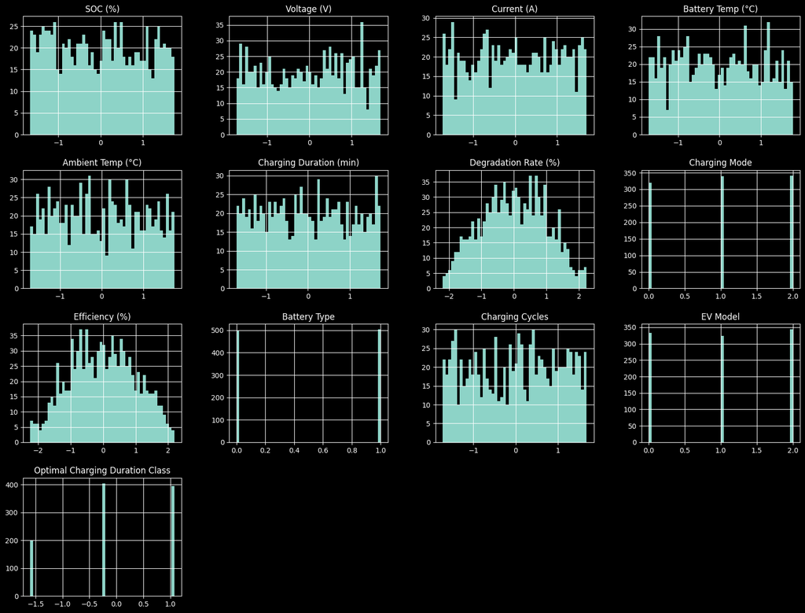

```python
## To detect skewness or unusual patterns in the data

processed_data.hist(bins=50, figsize=(20, 15))
```

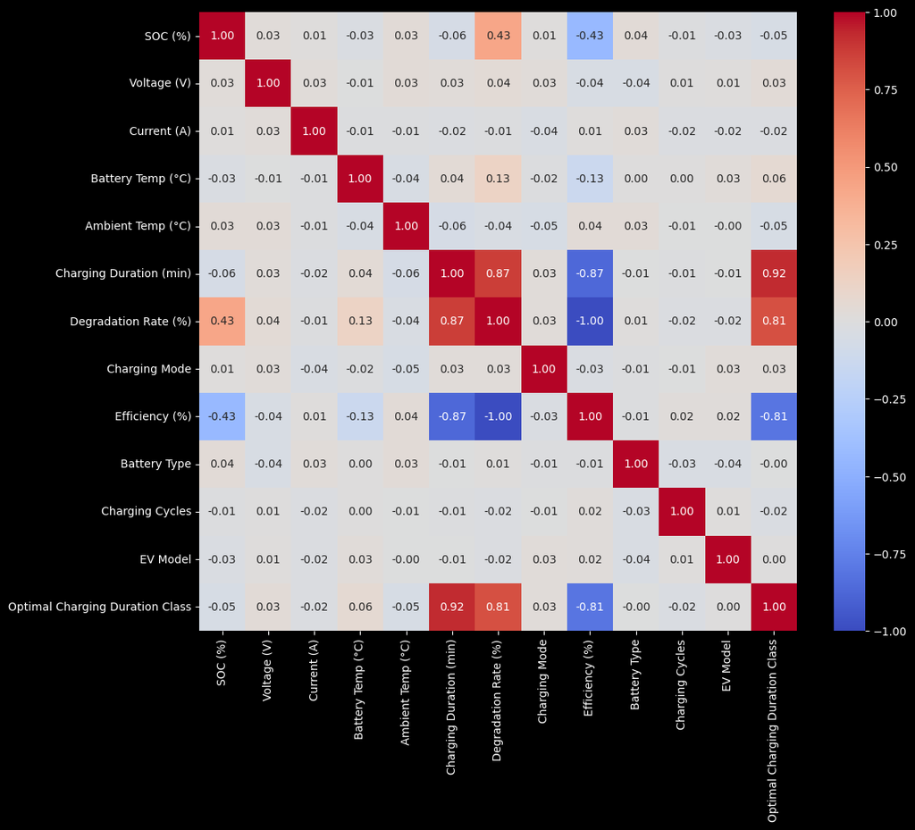

```python
## Identify highly correlated features
## Assess relationships between features and target variable

corr_matrix = processed_data.corr()

plt.figure(figsize=(12, 10))
sns.heatmap(corr_matrix, annot=True, cmap='coolwarm', fmt='.2f')
plt.show()
```

```python
## Extract highly correlated features
threshold = 0.8
high_corr = (corr_matrix.abs() > threshold) & (corr_matrix.abs() < 1.0)

high_corr_pairs = []
for col in high_corr.columns:
    correlated_features = high_corr.index[high_corr[col]].tolist()
    for feature in correlated_features:
        pair = tuple(sorted((col, feature)))
        if pair not in high_corr_pairs:
            high_corr_pairs.append(pair)

# print("Highly Correlated Pairs:", high_corr_pairs)
high_corr_features = list(set([feature for pair in high_corr_pairs for feature in pair]))
high_corr_features
```

```
['Optimal Charging Duration Class',
 'Charging Duration (min)',
 'Efficiency (%)',
 'Degradation Rate (%)']
```

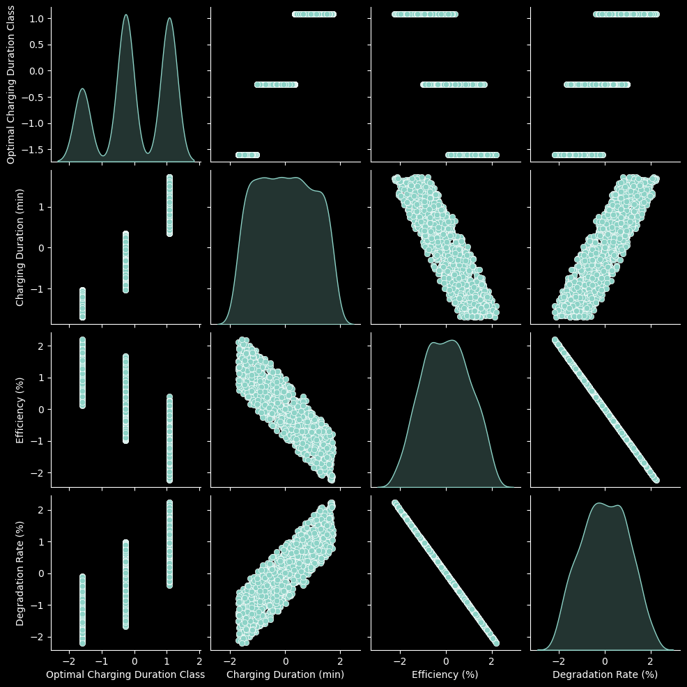

```python
## Plot paiplot for the high corr features
sns.pairplot(processed_data[high_corr_features], diag_kind='kde')
plt.show()
```

✅ How to read the Pairplot:  
• Diagonal plots (KDE plots) show the distribution of each individual variable.  
• Scatter plots (off-diagonal) represent relationships between two variables.

⸻

✅ Observations:

1. Optimal Charging Duration Class (Target)  
   • Clearly shows three distinct groups.  
   • These discrete clusters represent Short (0), Medium (1), and Long (2) duration classes.

⸻

✅ Relationships observed:  
• Charging Duration (min) and Efficiency (%).  
• Strong negative linear correlation: as duration increases, efficiency decreases. Longer charging durations may reduce battery efficiency.  
• Charging Duration vs Degradation Rate:  
• Positive linear correlation. Longer charging durations correlate with increased degradation rate.  
• Efficiency vs Degradation Rate:  
• Strong negative correlation (almost perfect line). As degradation rate increases, efficiency decreases sharply. Indicates that degradation directly affects efficiency.

⸻

✅ Practical Insights:  
• Shorter durations usually correlate with better efficiency and less degradation.  
• High degradation directly reduces efficiency, indicating the importance of minimizing degradation.  
• Battery efficiency and charging duration show clear inverse relationship.

⸻

✅ Actionable insights from this analysis:  
• Optimal charging practices should prioritize shorter charging times to maintain efficiency.  
• Strategies should consider balancing charging duration and acceptable degradation rates.

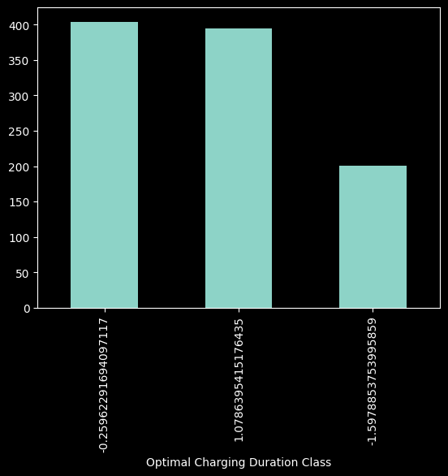

```python
## Identify if the classes are imbalanced
processed_data['Optimal Charging Duration Class'].value_counts().plot(kind='bar')
```

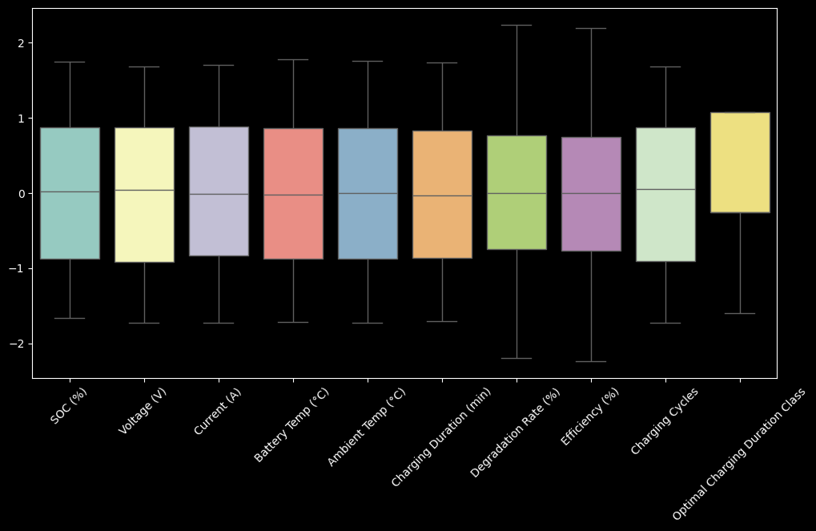

```python
## Spot and address potential anomalies

plt.figure(figsize=(12, 6))
sns.boxplot(data=processed_data[numerical_cols])
plt.xticks(rotation=45)  # Rotate labels for better readability
plt.show()
```

```python
## no apparent outliers to be seen
```

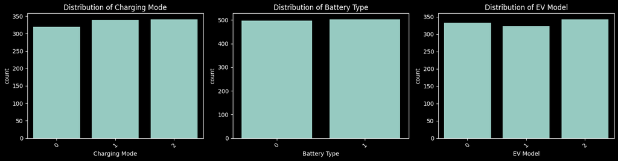

```python
## Categorical feature data analysis

plt.figure(figsize=(15, 4))
for i, col in enumerate(categorical_cols):
    plt.subplot(1, 3, i+1)
    sns.countplot(x=col, data=processed_data)
    plt.title(f'Distribution of {col}')
    plt.xticks(rotation=45)
plt.tight_layout()
plt.show()
```

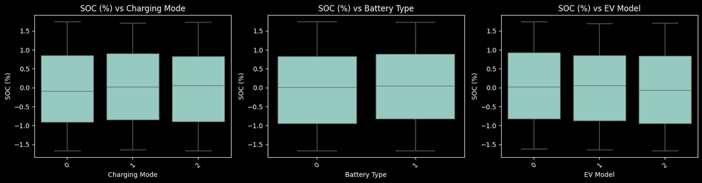

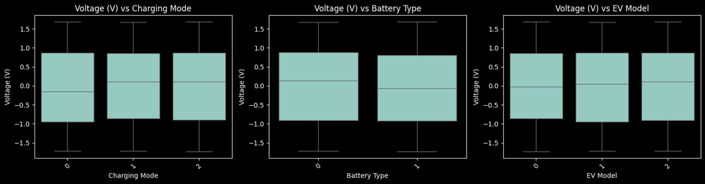

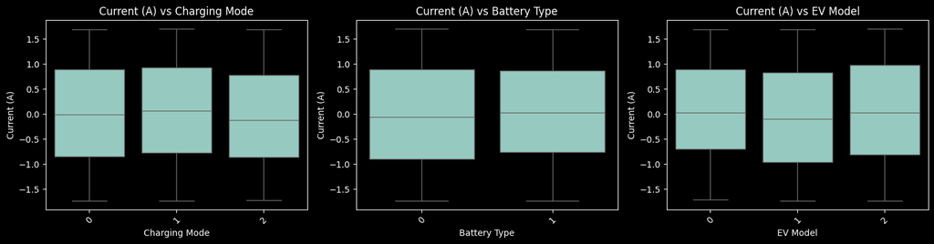

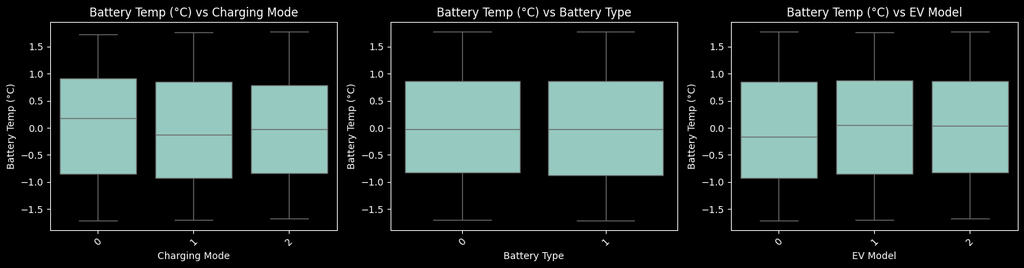

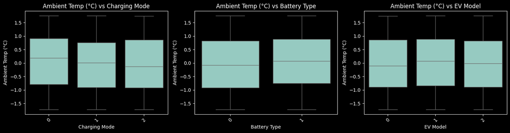

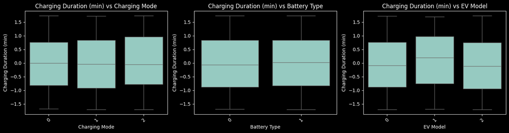

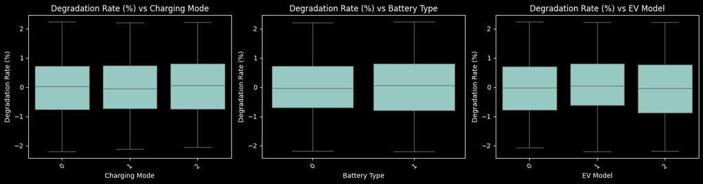

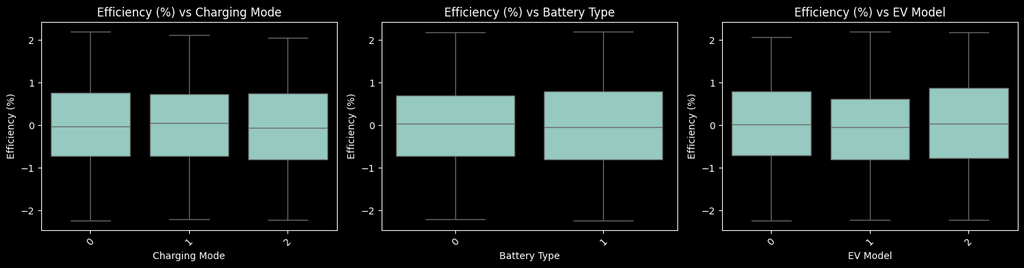

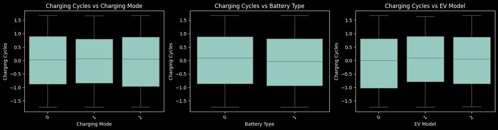

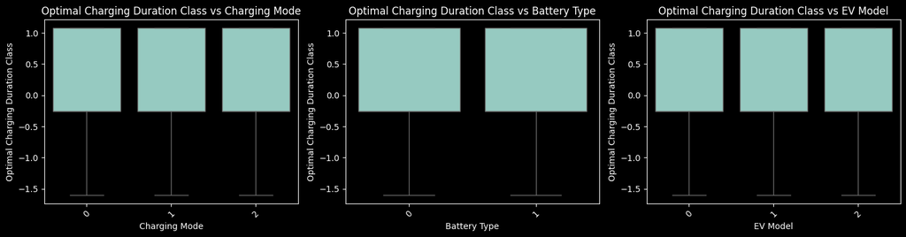

```python
# Plot boxplots for each categorical variable against key numerical features
for num_col in numerical_cols:
    plt.figure(figsize=(15, 4))
    for i, cat_col in enumerate(categorical_cols):
        plt.subplot(1, 3, i+1)
        sns.boxplot(x=cat_col, y=num_col, data=processed_data)
        plt.title(f'{num_col} vs {cat_col}')
        plt.xticks(rotation=45)
    plt.tight_layout()
    plt.show()
```

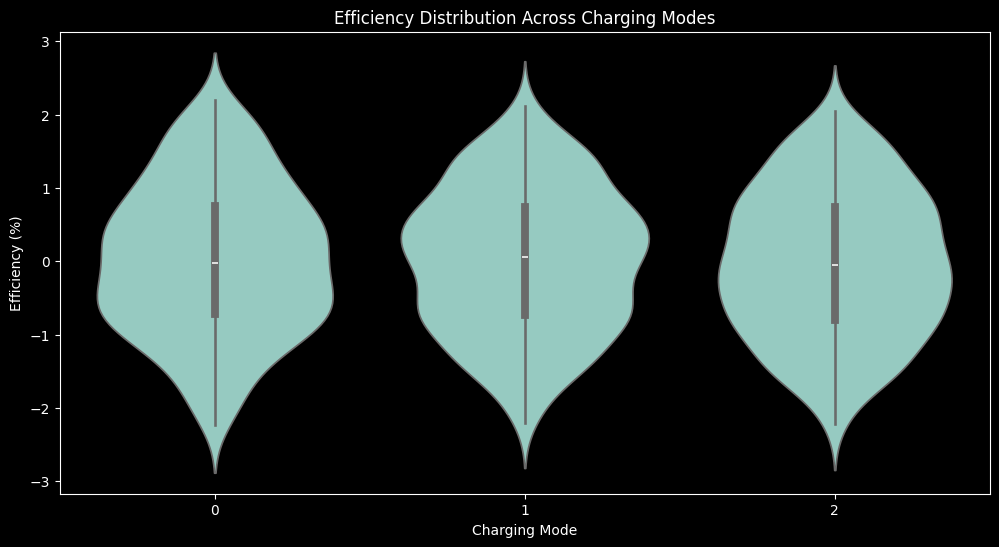

```python
plt.figure(figsize=(12, 6))
sns.violinplot(x='Charging Mode', y='Efficiency (%)', data=processed_data)
plt.title('Efficiency Distribution Across Charging Modes')
plt.show()
```

```python
## Since it does not vary accross modes, its not an important factor
```

```python
## To quantify the relationship between categorical and numerical features, perform ANOVA (Analysis of Variance).
for col in categorical_cols:
    f_stat, p_value = stats.f_oneway(*(processed_data[processed_data[col] == category]['Charging Duration (min)'] for category in processed_data[col].unique()))
    print(f'ANOVA result for {col}: F-stat={f_stat:.2f}, P-value={p_value:.4f}')
```

```
ANOVA result for Charging Mode: F-stat=0.56, P-value=0.5726
ANOVA result for Battery Type: F-stat=0.04, P-value=0.8337
ANOVA result for EV Model: F-stat=2.54, P-value=0.0791
```

1️⃣ Charging Mode (P-value = 0.5726)  
• P-value is high (>0.05) → Fail to reject H₀.  
• This means Charging Mode does not significantly impact the numeric feature being tested (e.g., Charging Duration (min)).  
• Conclusion: Charging Mode is not a strong predictor of the numeric variable tested.

⸻

2️⃣ Battery Type (P-value = 0.8337)  
• P-value is very high → No evidence that Battery Type affects the numeric feature.  
• Conclusion: Battery Type does not have a statistically significant effect on the numeric variable.

⸻

3️⃣ EV Model (P-value = 0.0791)  
• P-value is slightly above 0.05, meaning it’s close to being significant but not quite.  
• The EV Model might have some effect on the numeric variable, but it’s not strong enough to be statistically significant.  
• If more data was available, this effect might become significant.

⸻

✅ Final Insights  
1. None of the categorical variables significantly affect the numeric variable based on these p-values.  
2. EV Model shows some influence but is not statistically significant (P = 0.0791).  
3. Charging Mode and Battery Type are not useful predictors for the tested numeric variable.

### Explore questions and apply relevant models for testing

1. Battery Performance:  
   • What factors most significantly impact charging duration?  
   ['Degradation Rate (%)', 'Efficiency (%)', 'SOC (%)', 'Battery Temp (°C)']  
   • How does battery type (Li-ion vs. LiFePO4) influence optimal charging times?  
   It does not have any significant difference.

```python
# Define features and target
X = processed_data.drop(columns=['Charging Duration (min)'])
y = processed_data['Charging Duration (min)']

# Split the data
X_train, X_test, y_train, y_test = train_test_split(X, y, test_size=0.2, random_state=42)

# Train a Random Forest model
model = RandomForestRegressor(n_estimators=100, random_state=42)
model.fit(X_train, y_train)

# Extract feature importance
importances = model.feature_importances_
feature_names = X_train.columns

# Display sorted feature importance
sorted_features = sorted(zip(feature_names, importances), key=lambda x: x[1], reverse=True)
for feature, importance in sorted_features:
    print(f'{feature}: {importance:.4f}')
```

```
Optimal Charging Duration Class: 0.8657
SOC (%): 0.0430
Degradation Rate (%): 0.0403
Efficiency (%): 0.0367
Battery Temp (°C): 0.0049
Charging Cycles: 0.0020
Current (A): 0.0020
Ambient Temp (°C): 0.0020
Voltage (V): 0.0019
Charging Mode: 0.0006
EV Model: 0.0005
Battery Type: 0.0004
```

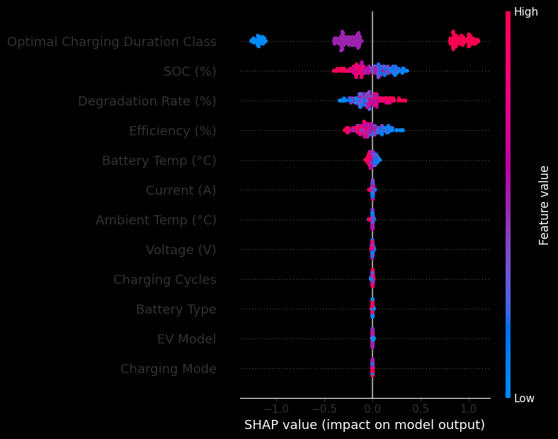

```python
## Better understanding of feature importance
explainer = shap.TreeExplainer(model)
shap_values = explainer.shap_values(X_test)
shap.summary_plot(shap_values, X_test)
```

```
Degradation Rate (%): 0.4776
Efficiency (%): 0.3444
SOC (%): 0.1631
Battery Temp (°C): 0.0071
Voltage (V): 0.0018
Charging Cycles: 0.0016
Ambient Temp (°C): 0.0016
Current (A): 0.0015
Charging Mode: 0.0005
EV Model: 0.0004
Battery Type: 0.0003
```

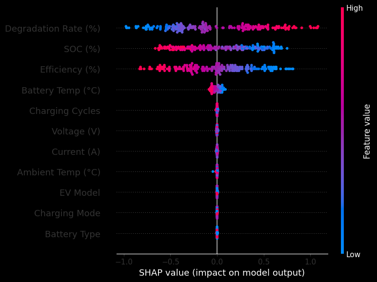

```python
## We will drop optimal charging as it directly affects the model
X = processed_data.drop(columns=['Optimal Charging Duration Class', 'Charging Duration (min)'])
y = processed_data['Charging Duration (min)']

# Split the data
X_train, X_test, y_train, y_test = train_test_split(X, y, test_size=0.2, random_state=42)

# Train a Random Forest model
model = RandomForestRegressor(n_estimators=100, random_state=42)
model.fit(X_train, y_train)

# Extract feature importance
importances = model.feature_importances_
feature_names = X_train.columns

# Display sorted feature importance
sorted_features = sorted(zip(feature_names, importances), key=lambda x: x[1], reverse=True)
for feature, importance in sorted_features:
    print(f'{feature}: {importance:.4f}')

# Running SHAP again
explainer = shap.TreeExplainer(model)
shap_values = explainer.shap_values(X_test)
shap.summary_plot(shap_values, X_test)
```

```
['Degradation Rate (%)', 'Efficiency (%)', 'SOC (%)', 'Battery Temp (°C)']
```

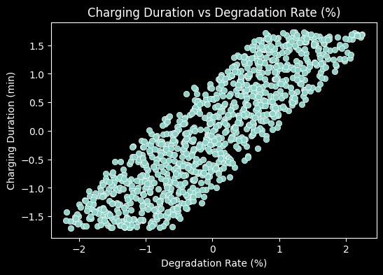

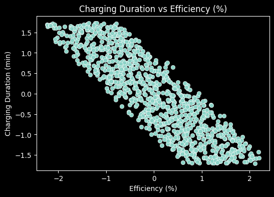

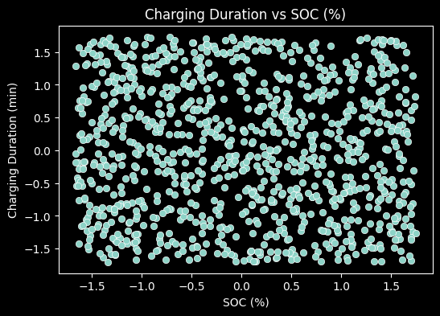

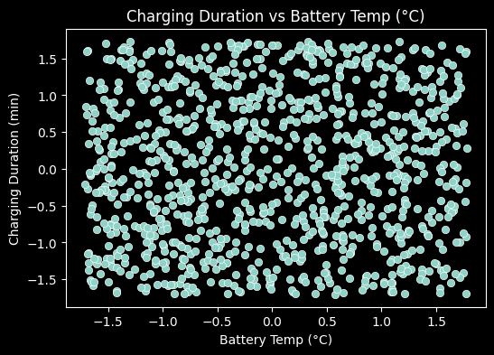

```python
# Select the top N features (e.g., top 4)
top_n = 4
top_features = [feature for feature, importance in sorted_features[:top_n]]
print(top_features)
for feature in top_features:
    plt.figure(figsize=(6,4))
    sns.scatterplot(x=processed_data[feature], y=processed_data['Charging Duration (min)'])
    plt.title(f'Charging Duration vs {feature}')
    plt.show()
```